# Скрипин Антон Вадимович Фт-360008

# Лабораторная работа - Проверка соответствия параметров интернет-соединения заявленным значениям

### Цели

**Часть 1: Определите, соответствует ли предоставленная скорость интернет-соединения оговоренной в контракте с Интернет-провайдером**

**Часть 2: Напишите отчет интернет-провайдеру (необязательно)**

### История/Cценарий

- В первой части этой лабораторной работы вы научитесь отвечать на вопросы, используя данные. Вы будете использовать описательную статистику и графики, чтобы определить скорость Интернета и визуализировать результаты. Ваш анализ будет проводиться с использованием Scikit-Learn, Pandas, и Matplotlib.
- Во второй части этой лабораторной работы вы узнаете, как сообщать о количественных результатах и как научно обосновать выводы. Вы отобразите свои результаты на графиках, убедившись, что они настолько ясны и проницательны, насколько это возможно. Вы будете генерировать качественные графики с помощью библиотеки Seaborn library или других, таких как FiveThirtyEight.

### Необходимые ресурсы

- 1 ПК с доступом в Интернет
- Библиотеки Python: datetime, pandas, numpy, pandas, scikit-learn, matplotlib, seaborn.
- Файлы данных: rpi_data_processed.csv
- Текстовый редактор для написания отчета

## Часть 1: Определите, соответствуют ли характеристики предоставленного интернет-соединения оговоренным в контракте с Интернет-провайдером

Вполне вероятно, что при заключении контракта с интернет-провайдером вы договорились с ним об определенном качестве обслуживания. Например, в договоре может быть указана максимальная скорость загрузки, которая может быть достигнута по вашему адресу. Первая часть этой лабораторной работы поможет вам ответить на вопрос: "Соответствует ли реальная скорость интернет-соединения заявленной в договоре?"

Начните с импорта необходимых библиотек.

```python
# import ...
import pandas as pd
from matplotlib import pylab as plt
import numpy as np
%matplotlib inline

# Выберите таблицу стилей для использования из библиотеки matplotlib, как это показано в главе 5.2.1.5
# или используйте метод, показанный в главе 5.2.1.4, чтобы создать собственную таблицу стилей.
```

##### Шаг 1: Импорт и очистка данных

Сформируйте кадр данных `df_compact` из файла `rpi_data_compact.csv`, который содержит измерения характеристик Интернет-соединения, необходимые для этой лабораторной работы.

```python
# Импортируйте данные из файла csv в кадр данных и отобразите первые несколько строк

df_compact = pd.read_csv('rpi_data_compact.csv', index_col=0)
df_compact.head()
```

|  | Ping (ms) | Download (Mbit/s) | Upload (Mbit/s) | Date | Time |
| --- | --- | --- | --- | --- | --- |
| 0 | 26.992 | 91.80 | 14.31 | 2016-11-24 | 13:36:25 |
| 1 | 24.532 | 88.19 | 14.12 | 2016-11-24 | 13:36:55 |
| 2 | 20.225 | 59.86 | 14.11 | 2016-11-24 | 13:37:25 |
| 3 | 19.332 | 91.81 | 14.22 | 2016-11-24 | 13:37:57 |
| 4 | 22.494 | 92.05 | 14.08 | 2016-11-24 | 13:38:27 |

Удалите лишний столбец индекса из кадра данных `df_compact`

```python
# Удалите дополнительный столбец индекса
#столбец удалили ранее при считывнии
```

Найдите и удалите любые нулевые значения из кадра данных `df_compact`

```python
# Сколько значений NaN в кадре данных?
print(df_compact.isnull().sum().sum())

# Удалить значения NaN
df_compact = df_compact.dropna()
```

```
23
```

Преобразуйте значения пинга и скорости загрузки в тип float Вы должны сохранить результат в новом файле с именем `rpi_data_processed.csv`.

```python
# Преобразуйте значения пинга и скорости загрузки в тип float
df_compact.loc[:, 'Ping (ms)'] = df_compact['Ping (ms)'].astype(float)
df_compact.loc[:, 'Download (Mbit/s)'] = df_compact['Download (Mbit/s)'].astype(float)

# Сохраните новый очищенный файл данных в csv под названием rpi_data_processed.csv.
# Обязательно используйте 'index=False', чтобы не создавать дополнительный столбец
df_compact.to_csv('rpi_data_processed.csv', index=False)
```

##### Шаг 2: Понятие заявленной скорости

Как правило, ваш провайдер не обещает гарантированную минимальную скорость интернета. Обычно он укажет только максимальную скорость интернета, которая может быть вам предоставлена. Возникает вопрос: 'Является ли мое интернет-соединение быстрее или медленнее, чем обещали?' и оценка качества обслуживания становится немного сложной.

Задачи ниже помогут вам выбрать **приемлемую скорость в Интернете**. Затем это значение будет использоваться для оценки того, предоставляет ли ваш провайдер приемлемый сервис.

- Проведите некоторые исследования, чтобы выяснить, какую скорость загрузки может быть разумно ожидаемой в вашей области. Также вы можете принять во внимание скорость интернета, необходимую для выполнения ваших задач. Например, сайты онлайн-потокового медиа обычно требуют скорость загрузки не менее 1.5 Мбит/с. Если вы считаете, что ваш контракт с интернет-провайдером должен позволять вам транслировать видео, то укажите это, как минимальное значение скорости соединения.
- Отобразите графически свои данные и определите значение минимально допустимой **скорости загрузки**, **скорости выгрузки** и **времени пинга**. Минимальные требования, которое вы выбрали ранее, также должны быть учтены.

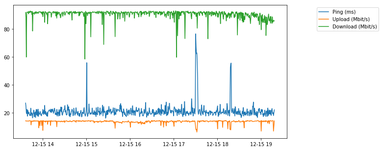

```python
# Инициализируйте график
fig, ax = plt.subplots(figsize=(10, 5))

# Постройте три кривые разных цветов
t = pd.to_datetime(df_compact['Time'])
ax.plot(t, df_compact['Ping (ms)'], label='Ping (ms)')
ax.plot(t, df_compact['Upload (Mbit/s)'], label='Upload (Mbit/s)')
ax.plot(t, df_compact['Download (Mbit/s)'], label='Download (Mbit/s)')

# Вынесите легенду за пределы основного графика
ax.legend(bbox_to_anchor=(1.1, 1.))
plt.show()
```

```python
# Сформируйте значения, которые вы считаете приемлемыми для характеристик Ineternet - трафика:
# Например:
acceptable_upload = 14 #Мбит/с
acceptable_download = 90 #Мбит/с
acceptable_ping = 20 #мс
```

##### Шаг 3: Сравнение предоставленной скорости с ожиданиями

У вас есть чистый набор данных и указаны допустимые значения. Это означает, что вы готовы начать основную часть анализа. Хорошая стратегия состоит в том, чтобы начать с простых задач и постепенно доходить до более сложных методов.

a) Постройте гистограммы для скорости загрузки, скорости выгрузки и времени пинга. На каждом из этих графиков укажите приемлемое значение для каждого измерения, используя вертикальную линию.

```
Text(0.5,1,'Upload (Mbit/s)')
```

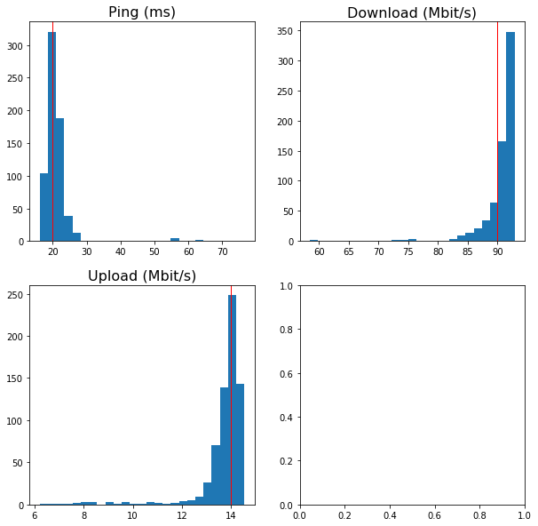

```python
# Инициализируйте график
fig, ax = plt.subplots(2, 2, figsize=(10, 10))

# Отобразите скорость пинга
ax[0][0].hist(df_compact['Ping (ms)'], 25)
# Отобразите приемлемое значение пинга
ax[0][0].axvline(acceptable_ping, color='red', linewidth=1)
ax[0][0].set_title('Ping (ms)', fontsize=16)

# Отобразите скорость загрузки
ax[0][1].hist(df_compact['Download (Mbit/s)'], 25)
# Отобразите приемлемое значение скорости загрузки
ax[0][1].axvline(acceptable_download, color='red', linewidth=1)
ax[0][1].set_title('Download (Mbit/s)', fontsize=16)

# Отобразите скорость выгрузки
ax[1][0].hist(df_compact['Upload (Mbit/s)'], 25)
# Отобразите приемлемое значение скорости выгрузки
ax[1][0].axvline(acceptable_upload, color='red', linewidth=1)
ax[1][0].set_title('Upload (Mbit/s)', fontsize=16)
```

b) Вычислите среднее значение и среднеквадратичное отклонение скорости загрузки, скорости выгрузки и времени пинга и рассчитайте, сколько среднеквадратичных отклонений отделяет приемлемые значения от средних.

```python
# вычислите среднее значение и среднеквадратичное отклонение для всех значений
means = df_compact[['Ping (ms)', 'Download (Mbit/s)', 'Upload (Mbit/s)']].mean()
stands = df_compact[['Ping (ms)', 'Download (Mbit/s)', 'Upload (Mbit/s)']].std()

# добавление меток улучшит понятность результатов
quote_ping = (means['Ping (ms)'], stands['Ping (ms)'])
quote_download = (means['Download (Mbit/s)'], stands['Download (Mbit/s)'])
quote_upload = (means['Upload (Mbit/s)'], stands['Upload (Mbit/s)'])

# выведите результаты на экран
print('Average ping time: {} ± {} ms'.format(*quote_ping))
# выведите Среднюю скорость загрузки на экран
print('Average download time: {} ± {} ms'.format(*quote_download))
# выведите Среднюю скорость выгрузки на экран
print('Average upload time: {} ± {} ms'.format(*quote_upload))
# пустая строка
print()
print('Расстояние между приемлемой скоростью пинга и средним значением: {:.2f} среднеквадратичных отклонений'.format((quote_ping[0]-acceptable_ping)/quote_ping[1]))
print('Расстояние между приемлемой скоростью загрузки и средним значением: {:.2f} среднеквадратичных отклонений'\
      .format((quote_download[0]-acceptable_download)/quote_download[1]))
print('Расстояние между приемлемой скоростью выгрузки и средним значением: {:.2f} среднеквадратичных отклонений'\
      .format((quote_upload[0]-acceptable_upload)/quote_upload[1]))
```

```
Average ping time: 21.115451708766724 ± 5.161225495663228 ms
Average download time: 90.44921248142644 ± 3.4656470318152284 ms
Average upload time: 13.697607726597328 ± 1.0804708853031768 ms

Расстояние между приемлемой скоростью пинга и средним значением: 0.22 среднеквадратичных отклонений
Расстояние между приемлемой скоростью загрузки и средним значением: 0.13 среднеквадратичных отклонений
Расстояние между приемлемой скоростью выгрузки и средним значением: -0.28 среднеквадратичных отклонений
```

c)Вычислите процентное значение скорости загрузки, которое неприемлемо. Повторите этот расчет для скорости выгрузки и скорости пинга.

```python
print('{:.2f}% измерений ниже допустимой скорости загрузки.'.format(np.sum(df_compact['Download (Mbit/s)']<acceptable_download)/float(len(df_compact))*100))
print('{:.2f}% измерений ниже допустимой скорости выгрузки.'.format(np.sum(df_compact['Upload (Mbit/s)']<acceptable_upload)/float(len(df_compact))*100))
print('{:.2f}% измерений ниже допустимого пинга.'.format(np.sum(df_compact['Ping (ms)']<acceptable_ping)/float(len(df_compact))*100))
```

```
22.29% измерений ниже допустимой скорости загрузки.
51.26% измерений ниже допустимой скорости выгрузки.
42.79% измерений ниже допустимого пинга.
```

d) Найдите сколько измерений в процентах не удовлетворяют вашим критериям приемлемого обслуживания по всем трем характеристикам.

```python
all_three = np.sum((df_compact['Ping (ms)']>acceptable_ping) & (df_compact['Download (Mbit/s)']<acceptable_download) & \
                   (df_compact['Upload (Mbit/s)']<acceptable_upload))
print('{:.2f}% измерений не приемлемы во всех трех случаях.'.format(all_three/float(len(df_compact))*100))
```

```
7.13% измерений не приемлемы во всех трех случаях.
```

e) Найдите сколько измерений в процентах не удовлетворяют вашим критериям приемлемого обслуживания по двум характеристикам из трех.

```python
ping_upload = np.sum((df_compact['Ping (ms)']>acceptable_ping) & (df_compact['Upload (Mbit/s)']<acceptable_upload))
print('{:.2f}% измерений неприемлемы для скорости пинга и скорости загрузки.'.format(ping_upload/float(len(df_compact))*100))

ping_download = np.sum((df_compact['Ping (ms)']>acceptable_ping) & (df_compact['Download (Mbit/s)']<acceptable_download))
print('{:.2f}% измерений неприемлемы для скорости пинга и скорости выгрузки.'.format(ping_download/float(len(df_compact))*100))

upload_download = np.sum((df_compact['Upload (Mbit/s)']>acceptable_upload) & (df_compact['Download (Mbit/s)']<acceptable_download))
print('{:.2f}% измерений неприемлемы для скорости выгрузки и скорости загрузки.'.format(upload_download/float(len(df_compact))*100))
```

[output not shown]

Теперь у вас есть хорошее представление о том, чего ожидать от вашего интернет-соединения, и вы знаете, что вам подходит, а что нет. Вы можете написать отчет, чтобы сообщить своему интернет-провайдеру, что происходит с вашим соединением. Вы сможете использовать все характеристики, которые вы вычислили в этой части лабораторной работы, и помимо этого, вы можете добавить те характеристики, которые, по вашему мнению, могут быть полезны.

## Часть 2: Напишите отчет интернет-провайдеру (необязательно)

Информирование и убеждение людей - очень ценное умение. Убеждение происходит почти всегда посредством логических аргументов, подтвержденных количественными доказательствами. Графики, статистика и численные результаты считаются профессиональным способом представления информации технической аудитории. Вторая часть этой лабораторной работы покажет вам как сообщать о количественных результатах и как убедить читателей в верности ваших аргументах на основе фактических данных.

Представьте, что вы пишете своему интернет-провайдеру, чтобы сообщить ему о качестве подключения к Интернету в вашем доме, школе или на рабочем месте. Этот отчет не должен превышать 800 слов и должен быть адресован человеку, имеющему некоторые знания математики и инженерии, но без знаний о машинном обучении. Поскольку вашего читателя будет не легко убедить, очень важно, чтобы вы подкрепляли свои заявления расчетами и графиками. Анализ, проведенный в части 1, поможет вам в этом.

Отчет должен быть структурирован следующим образом:

- Введение
- Методы
- Результаты
- Выводы

Элементы отчета будут более детально рассмотрены далее в лабораторной работе. Данная структура является достаточно общей, чтобы ее можно было использовать для написания научного отчета для других целей. Ознакомьтесь с ресурсами, перечисленными в самом конце блокнота, чтобы узнать больше.

### Введение

В введении должна быть описана ситуация, в отношении которой вы решили провести анализ. Также в нём кратко указываются итоги исследования. В хорошем введении не должно обсуждаться, как именно вы действовали, или описываться методы, которые вы использовали. Скорее, оно должно дать интуитивное понимание того, что мотивировало вас.

Вы также можете включить справочную информацию, которую вы собрали в Интернете, например, статистику о скорости Интернета в вашем регионе или на национальном уровне.

### Методы

Здесь расскажите, как вы пришли к своим выводам. Вы можете, например, объяснить, как вы определились с выбором параметров, которые для вас характеризуют 'приемлемый уровень подключения к Интернету'. Аналогичным образом, вы можете проиллюстрировать методы, используемые в Части 1, Шаг 3. Вы также можете сказать пару слов о данных, которые вы анализируете (как вы их собрали, их значение, частота сбора, временном интервале набора данных). Помните, что читатель имеет ограниченное знание статистики, и вам нужно будет найти простые способы для объяснения передовых концепций.

### Результаты

Здесь описываются результаты ваших расчетов и представлены графики, которые вы создали. Назовите свои графики так, чтобы было понятно, что на них отображено. Числовые результаты должны быть указаны в стандартном формате: $$\mathrm{quantity} = \mathrm{mean\ value} \pm \mathrm{standard\ deviation}.$$

Вы можете показать числовые результаты в таблицах, если считаете, что так они будут более понятны.

### Выводы

Это ваш последний шанс убедить читателя. Вы должны начать с краткого повторения того, что вы представили в отчете. Вы должны обобщить свои основные идеи и дать эффективное краткое описание доказательств, подтверждающих вашу позицию. Любые действия, которые вы хотели бы, чтобы их реализовал интернет-провайдера, должны быть запрошены здесь. Если вы критикуете некоторые моменты, убедитесь, что это делается конструктивно.

### Ресурсы

Ресурсы о том, как написать научный отчет:

- Scientific Report Writing, the Skills Team, University of Hull http://www2.hull.ac.uk/lli/pdf/Scientific%20Reports.pdf
- Writing scientific reports, The writer's handbook, http://writing.wisc.edu/Handbook/ScienceReport.html
- Writing a scientific report, Unifersity of New England, https://www.une.edu.au/__data/assets/pdf_file/0010/10324/WE_Writing-a-scientific-report.pdf

© 2017 Cisco and/or its affiliates. All rights reserved. This document is Cisco Public.